# Act 3

Samantha Martinez - A01235915, Antonio Maldonado - A01176753, Natalia Blanco - A01720531

3/9/2023

# Introducción

Un modelo de ecuaciones estructurales se utiliza para modelar relaciones complejas entre variables latentes y observadas. Esta técnica permite especificar relaciones causales entre variables, lo que la convierte en una herramienta poderosa para entender cómo diferentes factores pueden influir en un resultado de interés.

Algunas características del modelo SEM son las siguientes:

-Puede integrar múltiples ecuaciones simultáneamente en un solo modelo. -Permite especificar relaciones causales entre variables y evaluar su ajuste. -Proporciona medidas de ajuste para evaluar la calidad del modelo y determinar si se ajusta bien a los datos. - Puede utilizarse para realizar análisis predictivos y para evaluar el impacto de intervenciones o cambios en los factores que se están modelando.

Cargar librerias

Directorio

```r
setwd("C:/Users/ntybl/OneDrive/Documents/Semestre 8/Datos")
df=read.csv("data_fdi.csv")
```

Convertir los negativos a la media y promedio

```r
data_n <- df
data_n$business_activity <- replace(df$business_activity, df$business_activity <0, 0.18)
summary(data_n)
```

```
##     state                year       daily_wages     pop_density
##  Length:64          Min.   :2018   Min.   :259.3   Min.   :  10.36
##  Class :character   1st Qu.:2018   1st Qu.:302.5   1st Qu.:  40.74
##  Mode  :character   Median :2018   Median :329.2   Median :  65.54
##                     Mean   :2018   Mean   :335.4   Mean   : 308.96
##                     3rd Qu.:2019   3rd Qu.:357.3   3rd Qu.: 157.44
##                     Max.   :2019   Max.   :468.0   Max.   :6145.37
##  homocide_rate   employment_rate exchange_rate    patents_rate
##  Min.   : 1.99   Min.   :93.22   Min.   :19.11   Min.   : 0.163
##  1st Qu.:11.88   1st Qu.:96.36   1st Qu.:19.11   1st Qu.: 0.891
##  Median :20.66   Median :97.01   Median :19.61   Median : 1.728
##  Mean   :29.82   Mean   :96.94   Mean   :19.61   Mean   : 2.617
##  3rd Qu.:41.90   3rd Qu.:97.82   3rd Qu.:20.11   3rd Qu.: 3.273
##  Max.   :97.19   Max.   :99.39   Max.   :20.11   Max.   :13.766
##  border_distance   business_activity    new_fdi
##  Min.   :   8.83   Min.   :0.110     Min.   : -72.45
##  1st Qu.: 613.26   1st Qu.:0.180     1st Qu.:  84.29
##  Median : 751.64   Median :0.180     Median : 202.96
##  Mean   : 704.92   Mean   :1.286     Mean   : 388.30
##  3rd Qu.: 875.76   3rd Qu.:2.065     3rd Qu.: 475.89
##  Max.   :1252.66   Max.   :7.261     Max.   :3941.18
```

```r
data_n$new_fdi <- replace(df$new_fdi, df$new_fdi < 0, 202.96)
summary(data_n)
```

```
##     state                year       daily_wages     pop_density
##  Length:64          Min.   :2018   Min.   :259.3   Min.   :  10.36
##  Class :character   1st Qu.:2018   1st Qu.:302.5   1st Qu.:  40.74
##  Mode  :character   Median :2018   Median :329.2   Median :  65.54
##                     Mean   :2018   Mean   :335.4   Mean   : 308.96
##                     3rd Qu.:2019   3rd Qu.:357.3   3rd Qu.: 157.44
##                     Max.   :2019   Max.   :468.0   Max.   :6145.37
##  homocide_rate   employment_rate exchange_rate    patents_rate
##  Min.   : 1.99   Min.   :93.22   Min.   :19.11   Min.   : 0.163
##  1st Qu.:11.88   1st Qu.:96.36   1st Qu.:19.11   1st Qu.: 0.891
##  Median :20.66   Median :97.01   Median :19.61   Median : 1.728
##  Mean   :29.82   Mean   :96.94   Mean   :19.61   Mean   : 2.617
##  3rd Qu.:41.90   3rd Qu.:97.82   3rd Qu.:20.11   3rd Qu.: 3.273
##  Max.   :97.19   Max.   :99.39   Max.   :20.11   Max.   :13.766
##  border_distance   business_activity    new_fdi
##  Min.   :   8.83   Min.   :0.110     Min.   :   4.83
##  1st Qu.: 613.26   1st Qu.:0.180     1st Qu.:  93.61
##  Median : 751.64   Median :0.180     Median : 205.06
##  Mean   : 704.92   Mean   :1.286     Mean   : 396.00
##  3rd Qu.: 875.76   3rd Qu.:2.065     3rd Qu.: 475.89
##  Max.   :1252.66   Max.   :7.261     Max.   :3941.18
```

Convertir los datos a log

```r
data_n$daily_wages=log(data_n$daily_wages)
data_n$pop_density=log(data_n$pop_density)
data_n$employment_rate=log(data_n$employment_rate)
data_n$exchange_rate=log(data_n$exchange_rate)
data_n$border_distance=log(data_n$border_distance)
data_n$business_activity=log(data_n$business_activity)
data_n$new_fdi=log(data_n$new_fdi)
data_n$patents_rate=log(data_n$patents_rate)
summary(data_n)
```

```
##     state                year       daily_wages     pop_density
##  Length:64          Min.   :2018   Min.   :5.558   Min.   :2.338
##  Class :character   1st Qu.:2018   1st Qu.:5.712   1st Qu.:3.706
##  Mode  :character   Median :2018   Median :5.797   Median :4.177
##                     Mean   :2018   Mean   :5.807   Mean   :4.380
##                     3rd Qu.:2019   3rd Qu.:5.879   3rd Qu.:5.052
##                     Max.   :2019   Max.   :6.149   Max.   :8.723
##  homocide_rate   employment_rate exchange_rate    patents_rate
##  Min.   : 1.99   Min.   :4.535   Min.   :2.950   Min.   :-1.8140
##  1st Qu.:11.88   1st Qu.:4.568   1st Qu.:2.950   1st Qu.:-0.1158
##  Median :20.66   Median :4.575   Median :2.976   Median : 0.5463
##  Mean   :29.82   Mean   :4.574   Mean   :2.976   Mean   : 0.4996
##  3rd Qu.:41.90   3rd Qu.:4.583   3rd Qu.:3.001   3rd Qu.: 1.1854
##  Max.   :97.19   Max.   :4.599   Max.   :3.001   Max.   : 2.6222
##  border_distance business_activity    new_fdi
##  Min.   :2.178   Min.   :-2.2073   Min.   :1.575
##  1st Qu.:6.418   1st Qu.:-1.7148   1st Qu.:4.539
##  Median :6.622   Median :-1.7148   Median :5.323
##  Mean   :6.377   Mean   :-0.6490   Mean   :5.370
##  3rd Qu.:6.774   3rd Qu.: 0.7251   3rd Qu.:6.165
##  Max.   :7.133   Max.   : 1.9825   Max.   :8.279
```

# Estimación de Modelo de Ecuaciones Estructurales

Problema: Examinar los efectos que las variables como salario diario, densidad de población, tasa de empleo, tipo de cambio, distancia a frontera, tasa de patentes y actividad empresarial tienen en relación al fdi en México entre los años 2018 y 2019.

Hipótesis

- Incremento en actividad empresarial impactara positivamente el fdi
- Un salario mínimo bajo incrementara positivamente el fdi
- Una distancia a frontera corta afectara positivamente el fdi

Modelo 1 new_fdi, variable endogena = business_activity

```r
model5 <-'new_fdi ~ pop_density + border_distance + daily_wages + business_activity
business_activity ~ exchange_rate + employment_rate'
fit4 <- sem(model5,data=data_n)
varTable(fit4)
```

```
##                name idx nobs    type exo user   mean   var nlev lnam
## 1           new_fdi  11   64 numeric   0    0  5.370 1.339    0
## 2 business_activity  10   64 numeric   0    0 -0.649 1.796    0
## 3       pop_density   4   64 numeric   1    0  4.380 1.676    0
## 4   border_distance   9   64 numeric   1    0  6.377 0.757    0
## 5       daily_wages   3   64 numeric   1    0  5.807 0.017    0
## 6     exchange_rate   7   64 numeric   1    0  2.976 0.001    0
## 7   employment_rate   6   64 numeric   1    0  4.574 0.000    0
```

```r
summary(fit4, fit.measures=TRUE,standardized=TRUE,rsquare=TRUE)
```

```
## lavaan 0.6.14 ended normally after 1 iteration
##
##   Estimator                                         ML
##   Optimization method                           NLMINB
##   Number of model parameters                         8
##
##   Number of observations                            64
##
## Model Test User Model:
##
##   Test statistic                                 1.720
##   Degrees of freedom                                 5
##   P-value (Chi-square)                           0.886
##
## Model Test Baseline Model:
##
##   Test statistic                                29.479
##   Degrees of freedom                                11
##   P-value                                        0.002
##
## User Model versus Baseline Model:
##
##   Comparative Fit Index (CFI)                    1.000
##   Tucker-Lewis Index (TLI)                       1.391
##
## Loglikelihood and Information Criteria:
##
##   Loglikelihood user model (H0)               -194.820
##   Loglikelihood unrestricted model (H1)       -193.960
##
##   Akaike (AIC)                                 405.640
##   Bayesian (BIC)                               422.911
##   Sample-size adjusted Bayesian (SABIC)        397.732
##
## Root Mean Square Error of Approximation:
##
##   RMSEA                                          0.000
##   90 Percent confidence interval - lower         0.000
##   90 Percent confidence interval - upper         0.081
##   P-value H_0: RMSEA <= 0.050                    0.917
```

[output cut: 17 more lines]

```
##     daily_wages          3.342    1.104    3.028    0.002    3.342    0.375
##     business_ctvty       0.034    0.094    0.366    0.715    0.034    0.040
##   business_activity ~
##     exchange_rate       18.792    6.129    3.066    0.002   18.792    0.360
##     employment_rat      -2.805   12.764   -0.220    0.826   -2.805   -0.026
##
## Variances:
##                    Estimate  Std.Err  z-value  P(>|z|)   Std.lv  Std.all
##    .new_fdi           0.986    0.174    5.657    0.000    0.986    0.748
##    .business_ctvty    1.533    0.271    5.657    0.000    1.533    0.867
##
## R-Square:
##                    Estimate
##     new_fdi           0.252
##     business_ctvty    0.133
```

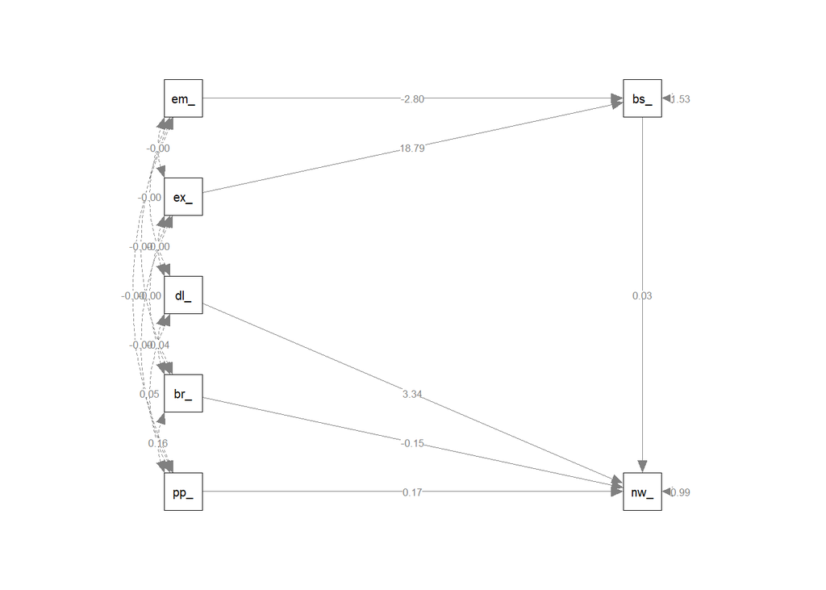

```r
semPaths(fit4,what="paths",whatLabels="par",style="lisrel",rotation=2)
```

Modelo 2 new_fdi, variable endogena = patents_rate

```r
model6 <-'new_fdi ~ pop_density + exchange_rate  + patents_rate + business_activity
patents_rate ~ border_distance + employment_rate'
fit5 <- sem(model6,data=data_n)
varTable(fit5)
```

```
##                name idx nobs    type exo user   mean   var nlev lnam
## 1           new_fdi  11   64 numeric   0    0  5.370 1.339    0
## 2      patents_rate   8   64 numeric   0    0  0.500 1.042    0
## 3       pop_density   4   64 numeric   1    0  4.380 1.676    0
## 4     exchange_rate   7   64 numeric   1    0  2.976 0.001    0
## 5 business_activity  10   64 numeric   1    0 -0.649 1.796    0
## 6   border_distance   9   64 numeric   1    0  6.377 0.757    0
## 7   employment_rate   6   64 numeric   1    0  4.574 0.000    0
```

```r
summary(fit5, fit.measures=TRUE,standardized=TRUE,rsquare=TRUE)
```

```
## lavaan 0.6.14 ended normally after 8 iterations
##
##   Estimator                                         ML
##   Optimization method                           NLMINB
##   Number of model parameters                         8
##
##   Number of observations                            64
##
## Model Test User Model:
##
##   Test statistic                                10.189
##   Degrees of freedom                                 5
##   P-value (Chi-square)                           0.070
##
## Model Test Baseline Model:
##
##   Test statistic                                16.393
##   Degrees of freedom                                11
##   P-value                                        0.127
##
## User Model versus Baseline Model:
##
##   Comparative Fit Index (CFI)                    0.038
##   Tucker-Lewis Index (TLI)                      -1.117
##
## Loglikelihood and Information Criteria:
##
##   Loglikelihood user model (H0)               -188.171
##   Loglikelihood unrestricted model (H1)       -183.076
##
##   Akaike (AIC)                                 392.342
##   Bayesian (BIC)                               409.613
##   Sample-size adjusted Bayesian (SABIC)        384.434
##
## Root Mean Square Error of Approximation:
##
##   RMSEA                                          0.127
##   90 Percent confidence interval - lower         0.000
##   90 Percent confidence interval - upper         0.240
##   P-value H_0: RMSEA <= 0.050                    0.117
```

[output cut: 17 more lines]

```
##     patents_rate     -0.033    0.135   -0.243    0.808   -0.033   -0.029
##     business_ctvty    0.047    0.111    0.427    0.669    0.047    0.055
##   patents_rate ~
##     border_distanc   -0.084    0.147   -0.568    0.570   -0.084   -0.071
##     employment_rat   -2.002   10.379   -0.193    0.847   -2.002   -0.024
##
## Variances:
##                    Estimate  Std.Err  z-value  P(>|z|)   Std.lv  Std.all
##    .new_fdi           1.203    0.213    5.657    0.000    1.203    0.911
##    .patents_rate      1.020    0.180    5.657    0.000    1.020    0.995
##
## R-Square:
##                    Estimate
##     new_fdi           0.089
##     patents_rate      0.005
```

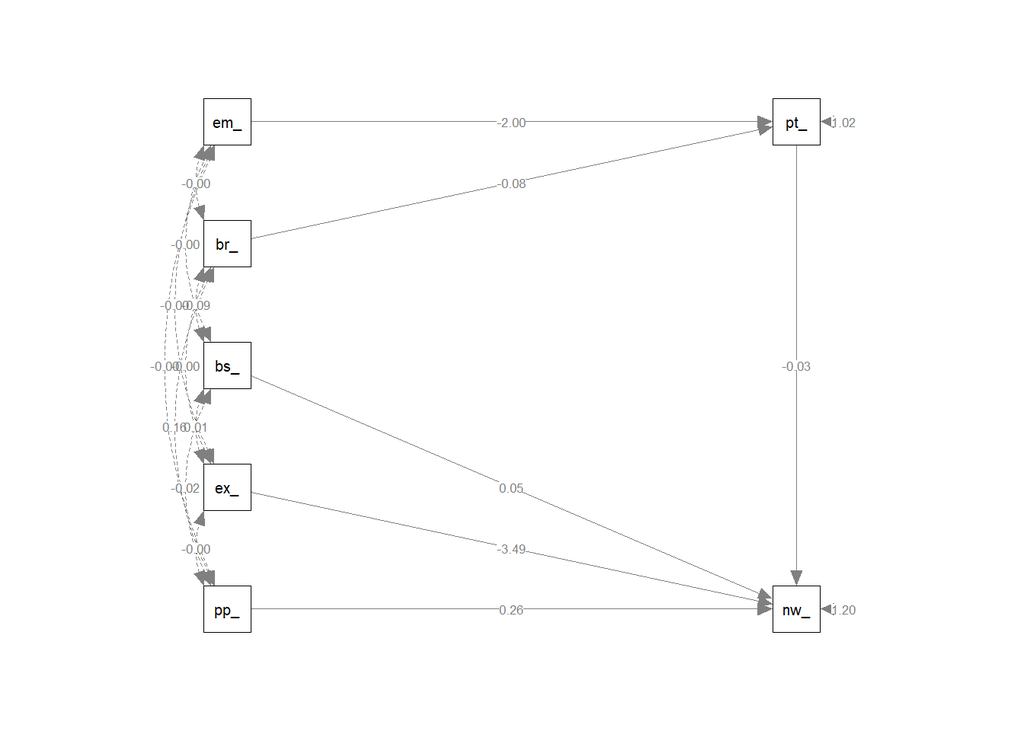

```r
semPaths(fit5,what="paths",whatLabels="par",style="lisrel",rotation=2)
```

# Pruebas de Diagnóstico

Modelo 1

```r
summary(fit4, fit.measures=TRUE,standardized=TRUE,rsquare=TRUE)
```

```
## lavaan 0.6.14 ended normally after 1 iteration
##
##   Estimator                                         ML
##   Optimization method                           NLMINB
##   Number of model parameters                         8
##
##   Number of observations                            64
##
## Model Test User Model:
##
##   Test statistic                                 1.720
##   Degrees of freedom                                 5
##   P-value (Chi-square)                           0.886
##
## Model Test Baseline Model:
##
##   Test statistic                                29.479
##   Degrees of freedom                                11
##   P-value                                        0.002
##
## User Model versus Baseline Model:
##
##   Comparative Fit Index (CFI)                    1.000
##   Tucker-Lewis Index (TLI)                       1.391
##
## Loglikelihood and Information Criteria:
##
##   Loglikelihood user model (H0)               -194.820
##   Loglikelihood unrestricted model (H1)       -193.960
##
##   Akaike (AIC)                                 405.640
##   Bayesian (BIC)                               422.911
##   Sample-size adjusted Bayesian (SABIC)        397.732
##
## Root Mean Square Error of Approximation:
##
##   RMSEA                                          0.000
##   90 Percent confidence interval - lower         0.000
##   90 Percent confidence interval - upper         0.081
##   P-value H_0: RMSEA <= 0.050                    0.917
```

[output cut: 17 more lines]

```
##     daily_wages          3.342    1.104    3.028    0.002    3.342    0.375
##     business_ctvty       0.034    0.094    0.366    0.715    0.034    0.040
##   business_activity ~
##     exchange_rate       18.792    6.129    3.066    0.002   18.792    0.360
##     employment_rat      -2.805   12.764   -0.220    0.826   -2.805   -0.026
##
## Variances:
##                    Estimate  Std.Err  z-value  P(>|z|)   Std.lv  Std.all
##    .new_fdi           0.986    0.174    5.657    0.000    0.986    0.748
##    .business_ctvty    1.533    0.271    5.657    0.000    1.533    0.867
##
## R-Square:
##                    Estimate
##     new_fdi           0.252
##     business_ctvty    0.133
```

Sabemos que en el modelo SEM se busca tener valores altos para el CFI y un valor bajo para el RMSEA y el AIC, así mismo se busca un R-Square alto ya que esto significa que el modelo es una buena representación de los datos y que las variables predictoras en el modelo son importantes para explicar la variable dependiente.

En el modelo anterior podemos observar lo siguiente:

CFI = 1.000

RMSEA = 0.000

AIC = 405.640

R-Square:

new_fdi = 0.252

business_ctvty = 0.133

Podemos concluir que este modelo presenta un alto CFI lo que nos lleva a la conclusión de que este modelo es excelente ya que el CFI varía entre 0 y 1, y se considera que un CFI mayor o igual a 0.90 indica un buen ajuste del modelo, aunque un CFI mayor o igual a 0,95 es considerado un ajuste excelente.

El RMSEA se expresa la desviación estándar de la población y varía entre 0 y 1 entre mas cerca del 0 este el RMSEA significa que el modelo tiene un mejor ajuste, considerando que el modelo 1 tiene un RMSEA de 0.00 podemos concluir que tiene un ajuste excelente.

AIC, cuanto menor sea el valor del AIC, mejor será el ajuste del modelo, es necesario comparar el AIC de diferentes modelos en este caso el AIC es de 405.6 lo cual es mayor al AIC del modelo 2.

R-Square, El R-squarer varía entre 0 y 1, un R-Square alto indica que el modelo es una buena representación de los datos en este caso se tienen R-Squares de 0.252 y 0.133 lo que indica un representación promedio.

Modelo 2

```r
summary(fit5, fit.measures=TRUE,standardized=TRUE,rsquare=TRUE)
```

```
## lavaan 0.6.14 ended normally after 8 iterations
##
##   Estimator                                         ML
##   Optimization method                           NLMINB
##   Number of model parameters                         8
##
##   Number of observations                            64
##
## Model Test User Model:
##
##   Test statistic                                10.189
##   Degrees of freedom                                 5
##   P-value (Chi-square)                           0.070
##
## Model Test Baseline Model:
##
##   Test statistic                                16.393
##   Degrees of freedom                                11
##   P-value                                        0.127
##
## User Model versus Baseline Model:
##
##   Comparative Fit Index (CFI)                    0.038
##   Tucker-Lewis Index (TLI)                      -1.117
##
## Loglikelihood and Information Criteria:
##
##   Loglikelihood user model (H0)               -188.171
##   Loglikelihood unrestricted model (H1)       -183.076
##
##   Akaike (AIC)                                 392.342
##   Bayesian (BIC)                               409.613
##   Sample-size adjusted Bayesian (SABIC)        384.434
##
## Root Mean Square Error of Approximation:
##
##   RMSEA                                          0.127
##   90 Percent confidence interval - lower         0.000
##   90 Percent confidence interval - upper         0.240
##   P-value H_0: RMSEA <= 0.050                    0.117
```

[output cut: 17 more lines]

```
##     patents_rate     -0.033    0.135   -0.243    0.808   -0.033   -0.029
##     business_ctvty    0.047    0.111    0.427    0.669    0.047    0.055
##   patents_rate ~
##     border_distanc   -0.084    0.147   -0.568    0.570   -0.084   -0.071
##     employment_rat   -2.002   10.379   -0.193    0.847   -2.002   -0.024
##
## Variances:
##                    Estimate  Std.Err  z-value  P(>|z|)   Std.lv  Std.all
##    .new_fdi           1.203    0.213    5.657    0.000    1.203    0.911
##    .patents_rate      1.020    0.180    5.657    0.000    1.020    0.995
##
## R-Square:
##                    Estimate
##     new_fdi           0.089
##     patents_rate      0.005
```

En el modelo anterior podemos observar lo siguiente:

CFI = 0.038

RMSEA = 0.127

AIC = 392.342

R-Square:

new_fdi = 0.089

patents_rate = 0.005

Este modelo presenta un CFI bajo lo que significa que este modelo no tiene un buen ajuste con los datos.

El AIC de este modelo es menor al AIC del modelo 1 ya que es menor.

R-Squares este modelo presenta R-Squares muy bajos sobre todo en comparación con el modelo 1 lo que significa que este modelo no es una buena representación de los datos.

# Selección de Modelo e Interpretación de Resultados

Se selecciono el modelo 1 ya que al comparar las pruebas de diagnóstico se llegó a la conclusión de que este modelo muestra un mejor desempeño en general, en el único aspecto que el modelo 2 es mejor que el modelo elegido fue en el valor del AIC sin embargo es una diferencia de 13.2, tomando en cuenta los otros resultados de diagnóstico que en este caso fueron CFI, RMSEA, AIC y R-Square se llego a la conclusión que el modelo con mejor desempeño es el modelo 1.

Modelo 1 new_fdi, variable endogena = business_activity

```r
summary(fit4, fit.measures=TRUE,standardized=TRUE,rsquare=TRUE)
```

```
## lavaan 0.6.14 ended normally after 1 iteration
##
##   Estimator                                         ML
##   Optimization method                           NLMINB
##   Number of model parameters                         8
##
##   Number of observations                            64
##
## Model Test User Model:
##
##   Test statistic                                 1.720
##   Degrees of freedom                                 5
##   P-value (Chi-square)                           0.886
##
## Model Test Baseline Model:
##
##   Test statistic                                29.479
##   Degrees of freedom                                11
##   P-value                                        0.002
##
## User Model versus Baseline Model:
##
##   Comparative Fit Index (CFI)                    1.000
##   Tucker-Lewis Index (TLI)                       1.391
##
## Loglikelihood and Information Criteria:
##
##   Loglikelihood user model (H0)               -194.820
##   Loglikelihood unrestricted model (H1)       -193.960
##
##   Akaike (AIC)                                 405.640
##   Bayesian (BIC)                               422.911
##   Sample-size adjusted Bayesian (SABIC)        397.732
##
## Root Mean Square Error of Approximation:
##
##   RMSEA                                          0.000
##   90 Percent confidence interval - lower         0.000
##   90 Percent confidence interval - upper         0.081
##   P-value H_0: RMSEA <= 0.050                    0.917
```

[output cut: 17 more lines]

```
##     daily_wages          3.342    1.104    3.028    0.002    3.342    0.375
##     business_ctvty       0.034    0.094    0.366    0.715    0.034    0.040
##   business_activity ~
##     exchange_rate       18.792    6.129    3.066    0.002   18.792    0.360
##     employment_rat      -2.805   12.764   -0.220    0.826   -2.805   -0.026
##
## Variances:
##                    Estimate  Std.Err  z-value  P(>|z|)   Std.lv  Std.all
##    .new_fdi           0.986    0.174    5.657    0.000    0.986    0.748
##    .business_ctvty    1.533    0.271    5.657    0.000    1.533    0.867
##
## R-Square:
##                    Estimate
##     new_fdi           0.252
##     business_ctvty    0.133
```

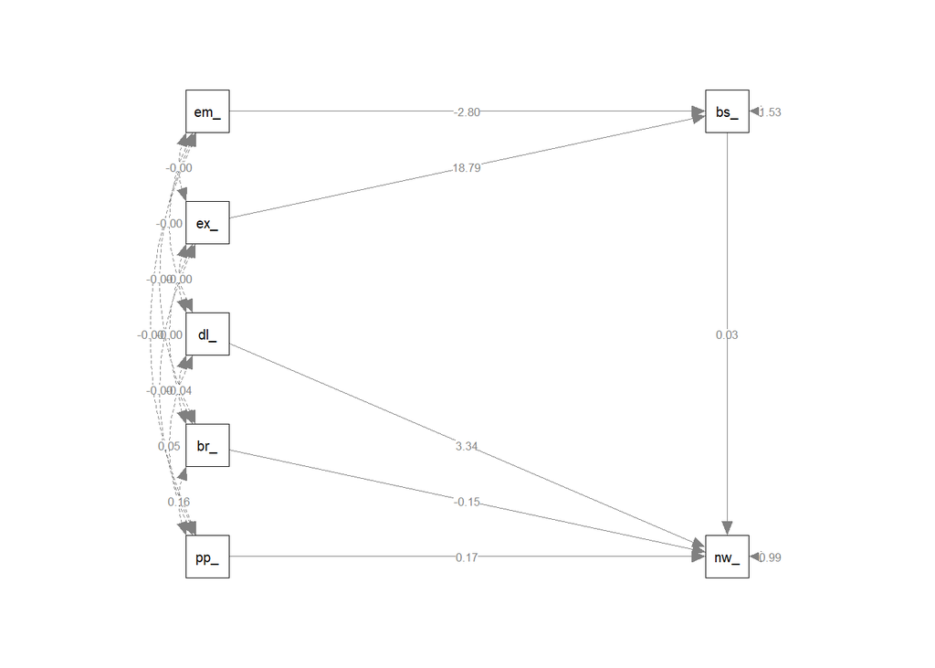

```r
semPaths(fit4,what="paths",whatLabels="par",style="lisrel",rotation=2)
```

# Conclusiones

En el análisis anterior tuvimos la oportunidad de analizar dos modelos SEM en los cuales se buscaba encontrar la relación de las variables y como estas afectaban el FDI, entendimos lo que es una variable endógena las cuales son variables que son afectadas por otras variables dentro de un modelo. Así mismo entendimos como analizar las pruebas de diagnostico y lo que cada una de ellas representa sobre el modelo.

# Referencias

Cheung, S. F., & Chio Lai, M. (2022, August 25). A Quick Start Guide on Using semptools. A quick start guide on using semptools. Retrieved March 12, 2023, from https://cran.r-project.org/web/packages/semptools/vignettes/semptools.html

Korstanje, J. (2021, June 27). Structural equation modeling. Medium. Retrieved March 12, 2023, from https://towardsdatascience.com/structural-equation-modeling-dca298798f4d#:~:text=What%20is%20Structural%20Equation%20Modeling,that%20cannot%20be%20measured%20directly